# Principal Component Analysis

```r
#install.packages("jsonlite", repos="https://cran.rstudio.com/")
library("jsonlite")
json_file <- 'https://datahub.io/machine-learning/vehicle/datapackage.json'
json_data <- fromJSON(paste(readLines(json_file), collapse=""))
```

```
incomplete final line found on 'https://datahub.io/machine-learning/vehicle/datapackage.json'
```

```r
# get list of all resources:
print(json_data$resources$name)
```

```
[1] "validation_report" "vehicle_csv"       "vehicle_json"
[4] "vehicle_zip"       "vehicle_arff"      "vehicle"
```

```r
# print all tabular data(if exists any)
for(i in 1:length(json_data$resources$datahub$type)){
  if(json_data$resources$datahub$type[i]=='derived/csv'){
    path_to_file = json_data$resources$path[i]
    data <- read.csv(url(path_to_file))
    print(data)
  }
}
```

| COMPACTNESS | CIRCULARITY | DISTANCE_CIRCULARITY | RADIUS_RATIO | PR.AXIS_ASPECT_RATIO | MAX.LENGTH_ASPECT_RATIO | SCATTER_RATIO | ELONGATEDNESS | PR.AXIS_RECTANGULARITY | MAX.LENGTH_RECTANGULARITY | SCALED_VARIANCE_MAJOR | SCALED_VARIANCE_MINOR | SCALED_RADIUS_OF_GYRATION | SKEWNESS_ABOUT_MAJOR | SKEWNESS_ABOUT_MINOR | KURTOSIS_ABOUT_MAJOR | KURTOSIS_ABOUT_MINOR | HOLLOWS_RATIO | Class |
| --- | --- | --- | --- | --- | --- | --- | --- | --- | --- | --- | --- | --- | --- | --- | --- | --- | --- | --- |
| 95 | 48 | 83 | 178 | 72 | 10 | 162 | 42 | 20 | 159 | 176 | 379 | 184 | 70 | 6 | 16 | 187 | 197 | van |
| 91 | 41 | 84 | 141 | 57 | 9 | 149 | 45 | 19 | 143 | 170 | 330 | 158 | 72 | 9 | 14 | 189 | 199 | van |
| 104 | 50 | 106 | 209 | 66 | 10 | 207 | 32 | 23 | 158 | 223 | 635 | 220 | 73 | 14 | 9 | 188 | 196 | saab |
| 93 | 41 | 82 | 159 | 63 | 9 | 144 | 46 | 19 | 143 | 160 | 309 | 127 | 63 | 6 | 10 | 199 | 207 | van |
| 85 | 44 | 70 | 205 | 103 | 52 | 149 | 45 | 19 | 144 | 241 | 325 | 188 | 127 | 9 | 11 | 180 | 183 | bus |
| 107 | 57 | 106 | 172 | 50 | 6 | 255 | 26 | 28 | 169 | 280 | 957 | 264 | 85 | 5 | 9 | 181 | 183 | bus |
| 97 | 43 | 73 | 173 | 65 | 6 | 153 | 42 | 19 | 143 | 176 | 361 | 172 | 66 | 13 | 1 | 200 | 204 | bus |
| 90 | 43 | 66 | 157 | 65 | 9 | 137 | 48 | 18 | 146 | 162 | 281 | 164 | 67 | 3 | 3 | 193 | 202 | van |
| 86 | 34 | 62 | 140 | 61 | 7 | 122 | 54 | 17 | 127 | 141 | 223 | 112 | 64 | 2 | 14 | 200 | 208 | van |
| 93 | 44 | 98 | 197 | 62 | 11 | 183 | 36 | 22 | 146 | 202 | 505 | 152 | 64 | 4 | 14 | 195 | 204 | saab |

[output cut: 836 more lines]

### Keep on ‘Saab’ and ‘bus’ classes

```r
library(dplyr)
dataset = data %>% filter(Class %in% c('saab','bus')) %>% transform(Class = ifelse(Class=="saab",0,1))
dataset = as.data.frame(sapply(dataset, as.numeric))
```

### split into training and testing

```r
# Spliting training and testing dataset
index = sample( 1:nrow( dataset ), nrow( dataset ) * 0.6, replace = FALSE )
trainset = dataset[ index, ]
test = dataset[ -index, ]
target = 'Class'
testset = setdiff(names(test),target)
```

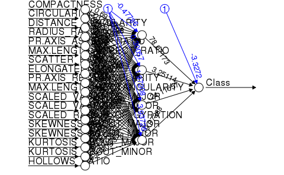

```r
# Building a neural network (NN)
library( neuralnet )
n = names( trainset )
f = as.formula( paste( "Class ~", paste( n[!n %in% "Class"], collapse = "+" ) ) )
nn = neuralnet( f, trainset, hidden = 4, linear.output = FALSE, threshold = 0.01 )
plot( nn, rep = "best" )
```

```r
# Testing the result output
nn.results = compute( nn, testset )
results = data.frame( actual = test$Class, prediction = round( nn.results$net.result ) )
# Confusion matrix
library( caret )
t = table( results )
print( confusionMatrix( t ) )
```

```
Confusion Matrix and Statistics

      prediction
actual  0  1
     0 86  2
     1 66 20

               Accuracy : 0.6091954
                 95% CI : (0.5324653, 0.6821382)
    No Information Rate : 0.8735632
    P-Value [Acc > NIR] : 1

                  Kappa : 0.2116205
 Mcnemar's Test P-Value : 0.00000000000002174375

            Sensitivity : 0.5657895
            Specificity : 0.9090909
         Pos Pred Value : 0.9772727
         Neg Pred Value : 0.2325581
             Prevalence : 0.8735632
         Detection Rate : 0.4942529
   Detection Prevalence : 0.5057471
      Balanced Accuracy : 0.7374402

       'Positive' Class : 0
```

## Let’s see if PCA can help us

Now, let’s perform the principal component analysis over the dataset and get the eigenvalues and eigenvectors. In a practical way, you will see that PCA function from R package provides a set of eigenvalues already sorted in descending order, it means that the first component is that one with the highest variance, the second component is the eigenvector with the second highest variance and so on. The code below shows how to chose the eigenvectors looking at the eigenvalues.

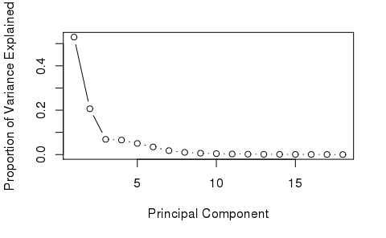

```r
# PCA
pca_trainset = trainset[,testsetcols]
pca_testset = testset
pca = prcomp( pca_trainset, scale = T )
# variance
pr_var = ( pca$sdev )^2
# % of variance
prop_varex = pr_var / sum( pr_var )
# Plot
plot( prop_varex, xlab = "Principal Component",
                  ylab = "Proportion of Variance Explained", type = "b" )
```

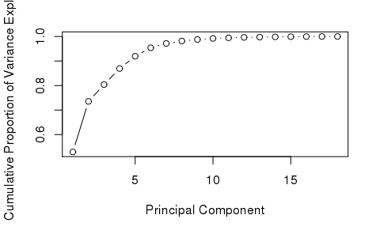

```r
# Scree Plot
plot( cumsum( prop_varex ), xlab = "Principal Component",
                            ylab = "Cumulative Proportion of Variance Explained", type = "b" )
```

The native R function “prcomp” from stats default packages performs PCA, it returns all eigenvalues and eigenvectors needed. The first plot shows the percentage of variance of each feature. You can see that the first component has the highest variance, something value around 50% while the 8th component is around of 0% of variance. So, it indicates that we should pick up the first eight components. The second figure show an another perspective of the variance, though the cumulative sum over all the variance, you can see that the first eight eigenvalues correspond to approximately 98% of the all variance. Indeed, it is a pretty good number, it means that there is just 2% of information being lost. The biggest beneficial is that we are moving from a space with eighteen features to another one with only eight feature losing only 2% of information. That is the power of dimensionality reduction, definitively.

Now that we know the number of the features that will compose the new space, let’s create the new dataset and then model the neural network again and check if we get new better outcomes.

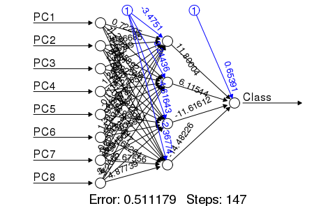

```r
# Creating a new dataset
train = data.frame( Class = trainset$Class, pca$x )
t = as.data.frame( predict( pca, newdata = pca_testset ) )
new_trainset = train[, 1:9]
new_testset =  t[, 1:8]
# Build the neural network (NN)
library( neuralnet )
n = names( new_trainset )
f = as.formula( paste( "Class ~", paste( n[!n %in% "Class" ], collapse = "+" ) ) )
nn = neuralnet( f, new_trainset, hidden = 4, linear.output = FALSE, threshold=0.01 )
# Plot the NN
plot( nn, rep = "best" )
```

```r
# Test the resulting output
nn.results = compute( nn, new_testset )
# Results
results = data.frame( actual = test$Class,
                      prediction = round( nn.results$net.result ) )
# Confusion Matrix
library( caret )
t = table( results )
print( confusionMatrix( t ) )
```

```
Confusion Matrix and Statistics

      prediction
actual  0  1
     0 84  4
     1  3 83

               Accuracy : 0.9597701
                 95% CI : (0.9188702, 0.9836749)
    No Information Rate : 0.5
    P-Value [Acc > NIR] : <0.0000000000000002

                  Kappa : 0.9195402
 Mcnemar's Test P-Value : 1

            Sensitivity : 0.9655172
            Specificity : 0.9540230
         Pos Pred Value : 0.9545455
         Neg Pred Value : 0.9651163
             Prevalence : 0.5000000
         Detection Rate : 0.4827586
   Detection Prevalence : 0.5057471
      Balanced Accuracy : 0.9597701

       'Positive' Class : 0
```

### Conclusion

Dimensionality Reduction plays a really important role in machine learning, especially when you are working with thousands of features. Principal Components Analysis are one of the top dimensionality reduction algorithm, it is not hard to understand and use it in real projects. This technique, in addition to making the work of feature manipulation easier, it still helps to improve the results of the classifier, as we saw in this post.

Finally, the answer of the initial questioning is yes, indeed Principal Component Analysis helps improve the outcome of a classifier.